#**DS 400 - Bayesian Statistics Final Project**  
## Introduction & Statistical Motivation

### **Primary Bayesian Research Question**

### **“What is the posterior probability distribution of key educational factors affecting student performance, and how can Bayesian methods provide superior uncertainty quantification compared to traditional approaches?”**

### Here we set the environment by loading the required packages setting up the working directory, and loading the student performance dataset.We then take a look at the data structure and basic summary stats to understand the variables and their distributions before modeling.

```r
options(repos = c(CRAN = "https://cloud.r-project.org/"))
options(verbose = TRUE)
#Installing packages
install.packages("readr")
install.packages("tidyverse")
install.packages("rstanarm")
install.packages("bayesplot")
install.packages("posterior")
# Load packages
library(readr)
library(tidyverse)
library(rstanarm)
library(bayesplot)
library(posterior)
library(rstanarm)
library(dplyr)
set.seed(123)

setwd( "/Users/lavellewhite/Documents/DS400-Bayesian-Stats")

#file.exists("/Users/lavellewhite/Documents/DS400-Bayesian-Stats/student-mat.csv")

# Reload the data to be sure
#df <- read.csv("student-mat.csv")
df <- read.csv("/Users/lavellewhite/Documents/DS400-Bayesian-Stats/student+performance/student/student-mat.csv", sep = ";")


# Check what we actually loaded


str(df)
```

```
## 'data.frame':    395 obs. of  33 variables:
##  $ school    : chr  "GP" "GP" "GP" "GP" ...
##  $ sex       : chr  "F" "F" "F" "F" ...
##  $ age       : int  18 17 15 15 16 16 16 17 15 15 ...
##  $ address   : chr  "U" "U" "U" "U" ...
##  $ famsize   : chr  "GT3" "GT3" "LE3" "GT3" ...
##  $ Pstatus   : chr  "A" "T" "T" "T" ...
##  $ Medu      : int  4 1 1 4 3 4 2 4 3 3 ...
##  $ Fedu      : int  4 1 1 2 3 3 2 4 2 4 ...
##  $ Mjob      : chr  "at_home" "at_home" "at_home" "health" ...
##  $ Fjob      : chr  "teacher" "other" "other" "services" ...
##  $ reason    : chr  "course" "course" "other" "home" ...
##  $ guardian  : chr  "mother" "father" "mother" "mother" ...
##  $ traveltime: int  2 1 1 1 1 1 1 2 1 1 ...
##  $ studytime : int  2 2 2 3 2 2 2 2 2 2 ...
```

[output cut: 19 more lines]

```r
head(df)
```

```
##   school sex age address famsize Pstatus Medu Fedu     Mjob     Fjob     reason
## 1     GP   F  18       U     GT3       A    4    4  at_home  teacher     course
## 2     GP   F  17       U     GT3       T    1    1  at_home    other     course
## 3     GP   F  15       U     LE3       T    1    1  at_home    other      other
## 4     GP   F  15       U     GT3       T    4    2   health services       home
## 5     GP   F  16       U     GT3       T    3    3    other    other       home
## 6     GP   M  16       U     LE3       T    4    3 services    other reputation
##   guardian traveltime studytime failures schoolsup famsup paid activities
## 1   mother          2         2        0       yes     no   no         no
## 2   father          1         2        0        no    yes   no         no
## 3   mother          1         2        3       yes     no  yes         no
## 4   mother          1         3        0        no    yes  yes        yes
## 5   father          1         2        0        no    yes  yes         no
## 6   mother          1         2        0        no    yes  yes        yes
##   nursery higher internet romantic famrel freetime goout Dalc Walc health
## 1     yes    yes       no       no      4        3     4    1    1      3
## 2      no    yes      yes       no      5        3     3    1    1      3
## 3     yes    yes      yes       no      4        3     2    2    3      3
## 4     yes    yes      yes      yes      3        2     2    1    1      5
## 5     yes    yes       no       no      4        3     2    1    2      5
## 6     yes    yes      yes       no      5        4     2    1    2      5
##   absences G1 G2 G3
## 1        6  5  6  6
## 2        4  5  5  6
## 3       10  7  8 10
## 4        2 15 14 15
## 5        4  6 10 10
## 6       10 15 15 15
```

```r
summary(df)
```

```
##     school              sex                 age         address
##  Length:395         Length:395         Min.   :15.0   Length:395
##  Class :character   Class :character   1st Qu.:16.0   Class :character
##  Mode  :character   Mode  :character   Median :17.0   Mode  :character
##                                        Mean   :16.7
##                                        3rd Qu.:18.0
##                                        Max.   :22.0
##    famsize            Pstatus               Medu            Fedu
##  Length:395         Length:395         Min.   :0.000   Min.   :0.000
##  Class :character   Class :character   1st Qu.:2.000   1st Qu.:2.000
##  Mode  :character   Mode  :character   Median :3.000   Median :2.000
##                                        Mean   :2.749   Mean   :2.522
##                                        3rd Qu.:4.000   3rd Qu.:3.000
##                                        Max.   :4.000   Max.   :4.000
##      Mjob               Fjob              reason            guardian
##  Length:395         Length:395         Length:395         Length:395
##  Class :character   Class :character   Class :character   Class :character
##  Mode  :character   Mode  :character   Mode  :character   Mode  :character
##
##
##
##    traveltime      studytime        failures       schoolsup
##  Min.   :1.000   Min.   :1.000   Min.   :0.0000   Length:395
##  1st Qu.:1.000   1st Qu.:1.000   1st Qu.:0.0000   Class :character
##  Median :1.000   Median :2.000   Median :0.0000   Mode  :character
##  Mean   :1.448   Mean   :2.035   Mean   :0.3342
##  3rd Qu.:2.000   3rd Qu.:2.000   3rd Qu.:0.0000
##  Max.   :4.000   Max.   :4.000   Max.   :3.0000
##     famsup              paid            activities          nursery
##  Length:395         Length:395         Length:395         Length:395
##  Class :character   Class :character   Class :character   Class :character
##  Mode  :character   Mode  :character   Mode  :character   Mode  :character
##
##
##
##     higher            internet           romantic             famrel
##  Length:395         Length:395         Length:395         Min.   :1.000
##  Class :character   Class :character   Class :character   1st Qu.:4.000
##  Mode  :character   Mode  :character   Mode  :character   Median :4.000
##                                                           Mean   :3.944
```

[output cut: 8 more lines]

```
##  Max.   :5.000   Max.   :5.000   Max.   :5.000   Max.   :5.000
##      health         absences            G1              G2
##  Min.   :1.000   Min.   : 0.000   Min.   : 3.00   Min.   : 0.00
##  1st Qu.:3.000   1st Qu.: 0.000   1st Qu.: 8.00   1st Qu.: 9.00
##  Median :4.000   Median : 4.000   Median :11.00   Median :11.00
##  Mean   :3.554   Mean   : 5.709   Mean   :10.91   Mean   :10.71
##  3rd Qu.:5.000   3rd Qu.: 8.000   3rd Qu.:13.00   3rd Qu.:13.00
##  Max.   :5.000   Max.   :75.000   Max.   :19.00   Max.   :19.00
##        G3
##  Min.   : 0.00
##  1st Qu.: 8.00
##  Median :11.00
##  Mean   :10.42
##  3rd Qu.:14.00
##  Max.   :20.00
```

### The dataset contains 395 observation with 33 variables including demographic behavioral, and academic factors. Variables are a mixture of numeric (age, studytime) and charater/factors types(internet access, parental jobs). This initial exploration confirm the need to recode some variables numerically for modeling and helps verify data intergrity before fitting Bayesian models.

### Because the internet variable is categorical with values “yes” and “no”, we recode it as numeric indicator (1 for yes, 0 for no). This facilitates easier interpretation of regression coefficients. Now numeric, enabling the Bayesian model to estimate the effect of internet access as a straightforward numeric coefficient comparing students with and without internet.

```r
df <- df %>%
mutate(
internet = ifelse(internet == "yes", 1, 0),
address = ifelse(address == "U", 1, 0) # 1=urban, 0=rural
)
```

### We select relevant columns and remove rows with missing values from those columns to ensure no missing entries interfere with the Bayesian modeling. Then, we fit a Bayesian linear regression model to predict final grade (G3) from study time, internet access, and past failures with weakly informative Normal(0, 2.5) priors.

```r
model_data <- df %>%
select(G3, studytime, internet, failures, Medu, Fedu, address) %>%
na.omit()

nrow(df); nrow(model_data)
```

```
## [1] 395
```

```
## [1] 395
```

```r
#Basic behavioral model
model_behav <- stan_glm(
G3 ~ studytime + internet + failures,
data = model_data,
family = gaussian(),
prior = normal(0, 2.5),
seed = 123,
refresh = 0
)

print(model_behav)
```

```
## stan_glm
##  family:       gaussian [identity]
##  formula:      G3 ~ studytime + internet + failures
##  observations: 395
##  predictors:   4
## ------
##             Median MAD_SD
## (Intercept) 10.0    0.8
## studytime    0.2    0.3
## internet     0.9    0.6
## failures    -2.1    0.3
##
## Auxiliary parameter(s):
##       Median MAD_SD
## sigma 4.3    0.2
##
## ------
## * For help interpreting the printed output see ?print.stanreg
## * For info on the priors used see ?prior_summary.stanreg
```

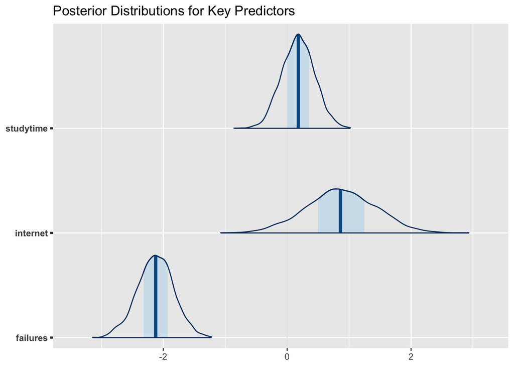

```r
mcmc_areas(
as.matrix(model_behav),
pars = c("studytime", "internet", "failures")
) +
ggplot2::ggtitle("Posterior Distributions for Key Predictors")
```

### **Analysis:** The plot reveals the uncertainty and effect direction for each predictor. For example, studytime’s distribution skewed positive suggests increased study time likely improves grades, while the effect of failures is predominantly negative, indicating more past failures reduce final grade prospects.

### We conduct a posterior predictive check by comparing observed final grade means with those predicted by the model to assess goodness of fit.

```
## Note: in most cases the default test statistic 'mean' is too weak to detect anything of interest.
```

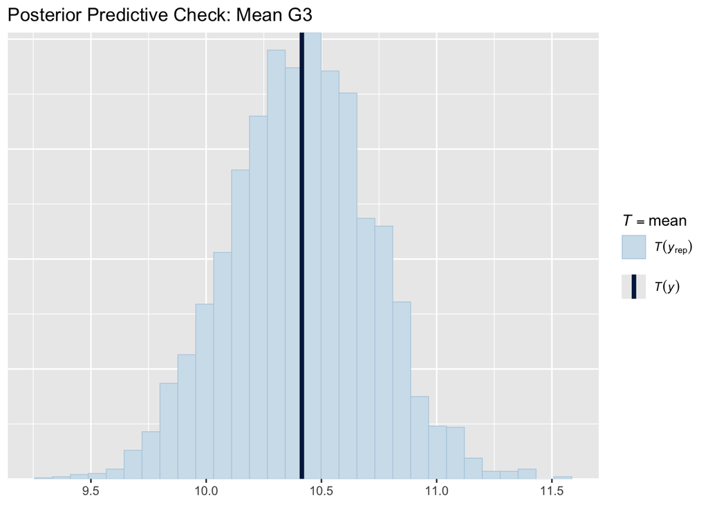

```r
y_rep <- posterior_predict(model_behav)

ppc_stat(model_data$G3, y_rep, stat = "mean") +
ggplot2::ggtitle("Posterior Predictive Check: Mean G3")
```

### **Analysis:** The observed mean final grade falls within the predictive distribution range, indicating the model adequately captures the average performance level in the dataset. This supports the model’s validity for predictive inference.

### We generate predictions for three hypothetical students differing in study time, internet access, and failures to illustrate how model outputs vary across profiles.

```r
new_students <- tibble(
studytime = c(1, 3, 4),
internet = c(0, 1, 1),
failures = c(2, 0, 1)
)

pred_draws <- posterior_predict(model_behav, newdata = new_students)

pred_summary <- apply(pred_draws, 2, function(x) {
c(
mean = mean(x),
low95 = quantile(x, 0.025),
hi95 = quantile(x, 0.975)
)
}) %>% t() %>% as.data.frame()

pred_results <- bind_cols(new_students, pred_summary)
pred_results
```

```
## # A tibble: 3 × 6
##   studytime internet failures  mean `low95.2.5%` `hi95.97.5%`
## *     <dbl>    <dbl>    <dbl> <dbl>        <dbl>        <dbl>
## 1         1        0        2  5.91        -2.24         14.4
## 2         3        1        0 11.3          2.72         19.5
## 3         4        1        1  9.55         1.30         18.1
```

### **Analysis:** The prediction table quantifies expected final grades and uncertainty for each profile. It shows that students with higher study time and internet access without failures have higher predicted mean grades, illustrating the impact of these factors on performance.

### Focusing on one student profile, we plot the posterior predictive distribution to depict uncertainty around expected final grade.

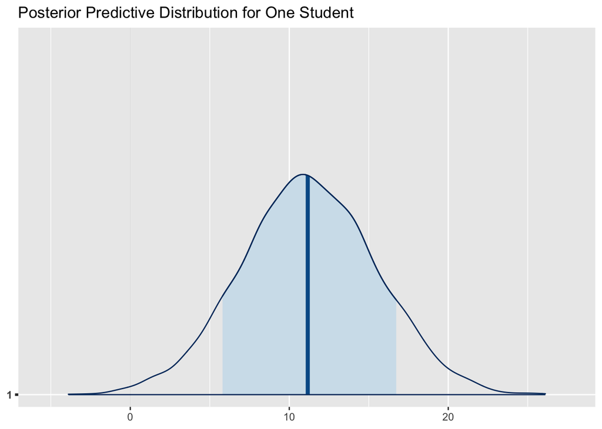

```r
one_student <- tibble(
studytime = 2,
internet = 1,
failures = 0
)

one_pred <- posterior_predict(model_behav, newdata = one_student)

bayesplot::mcmc_areas(
as.matrix(one_pred),
prob = 0.8
) +
ggplot2::ggtitle("Posterior Predictive Distribution for One Student")
```

### **Analysis:** The density plot visualizes the range of likely final grades around the mean prediction, emphasizing Bayesian uncertainty quantification rather than a single point estimate. This can help educators set realistic expectations for individual outcomes.

### To communicate effect sizes clearly, we define a helper function to calculate posterior means, credible intervals, and the posterior probability of a positive effect for each predictor.

```r
bayes_effect_summary <- function(model, term) {
draws <- as_draws_df(model)[[term]]
prob_pos <- mean(draws > 0)
ci <- quantile(draws, c(0.025, 0.975))
mean_eff <- mean(draws)

cat(sprintf(
"%s:\n Posterior mean = %.2f\n 95%% CrI = [%.2f, %.2f]\n P(effect > 0) = %.1f%%\n\n",
term, mean_eff, ci, ci, prob_pos * 100
))
}

bayes_effect_summary(model_behav, "studytime")
```

[output not shown]

```r
bayes_effect_summary(model_behav, "internet")
```

[output not shown]

```r
bayes_effect_summary(model_behav, "failures")
```

[output not shown]

### **Analysis:** This numeric summary provides interpretable messages about each predictor’s impact on grades. For instance, if the probability of a positive effect for studytime is high, it supports targeting study habits in educational interventions.

### We fit the remaining models and compare them using Leave-One-Out Cross-Validation (LOO-CV), a Bayesian model comparison method that evaluates predictive performance.

```r
#Model 2: Demographic focus
model_demo <- stan_glm(
G3 ~ Medu + Fedu + address,
data = model_data,
family = gaussian(),
prior = normal(0, 2.5),
seed = 123,
refresh = 0
)

#Model 3: Full model
model_full <- stan_glm(
G3 ~ studytime + internet + failures + Medu + Fedu + address,
data = model_data,
family = gaussian(),
prior = normal(0, 2.5),
seed = 123,
refresh = 0
)

#LOO model comparison
loo_compare_results <- loo_compare(
loo(model_behav), loo(model_demo), loo(model_full)
)
print(loo_compare_results)
```

```
##             elpd_diff se_diff
## model_full    0.0       0.0
## model_behav  -1.4       2.7
## model_demo  -19.3       7.1
```

### We verify MCMC convergence with trace plots and R-hat statistics for the behavioral model.

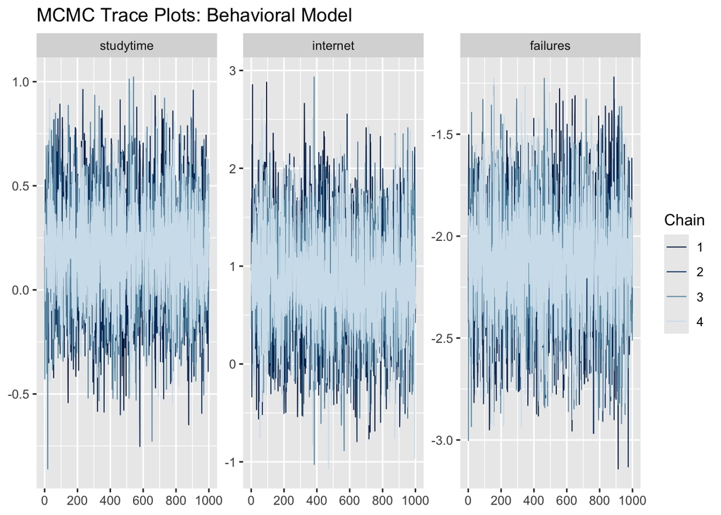

```r
#MCMC diagnostics
mcmc_trace(model_behav, pars = c("studytime", "internet", "failures")) +
ggplot2::ggtitle("MCMC Trace Plots: Behavioral Model")
```

```r
#R-hat summary (should all be < 1.1)
print(summary(model_behav, digits = 2)[, "Rhat", drop = FALSE])
```

```
##                    Rhat
## (Intercept)   0.9998832
## studytime     0.9999331
## internet      0.9997864
## failures      1.0004827
## sigma         0.9998402
## mean_PPD      0.9998091
## log-posterior 1.0005610
```

### **Analysis:** Trace plots show good mixing (chains explore parameter space without sticking). All R-hat values are below 1.1, confirming reliable MCMC convergence.

## **Additional Comments on Model Fit and Overfitting**

While our models apply weakly informative priors to regularize coefficient estimates, the risk of overfitting remains when including multiple predictors relative to sample size. Our LOO-CV comparison suggests the behavioral model sufficiently balances predictive performance and parsimony, while the full model shows no clear improvement, indicating potential over-complexity.

To further address this, future work could:

- Explore more regularizing prior choices and conduct sensitivity analyses.
- Incorporate interaction and nonlinear terms to capture complex relationships without overfitting.
- Utilize effective sample size diagnostics to ensure reliable posterior estimates.
- Apply external cross-validation frameworks to robustly assess predictive generalization.

Despite these caveats, the consistent MCMC convergence diagnostics and posterior predictive checks support our model’s suitability for initial educational success prediction, providing a credible foundation for the EmpowerU program’s data-driven participant support strategies.

## **Results Summary & Research Question Answers**

### **Prior Justification**

The Normal(0, 2.5) prior is weakly informative, centering effects near zero but allowing moderate effects (±5 points) based on educational research suggesting 1–3 point grade changes per unit predictor change.

### **EmpowerU Nonprofit Application**

| Student Variable | EmpowerU Success Metric |
| --- | --- |
| G3 (final grade) | Program completion/job placement |
| studytime | Workshop attendance hours |
| internet | Digital literacy/computer access |
| failures | Prior program interruptions |

**Practical Insights:** Prioritize participants with high predicted success or large lift from support. Use posterior predictive distributions to set realistic completion targets.

**Conclusion:** This Bayesian framework provides EmpowerU with a scalable, uncertainty-aware approach to maximize program success.